# Risk Factor Analysis

## Outcome Variable

**Outcome Variable:** wast_rec90d

## Predictor Variables

**Intervention Variable:** hdlvry

**Adjustment Set:**

unadjusted

## Stratifying Variables

The analysis was stratified on these variable(s):

- agecat
- studyid
- country

## Data Summary

| agecat | studyid | country | hdlvry | wast_rec90d | n_cell | n |
| --- | --- | --- | --- | --- | --- | --- |
| 0-24 months | CMC-V-BCS-2002 | INDIA | 0 | 0 | 115 | 320 |
| 0-24 months | CMC-V-BCS-2002 | INDIA | 0 | 1 | 199 | 320 |
| 0-24 months | CMC-V-BCS-2002 | INDIA | 1 | 0 | 4 | 320 |
| 0-24 months | CMC-V-BCS-2002 | INDIA | 1 | 1 | 2 | 320 |
| 0-24 months | COHORTS | INDIA | 0 | 0 | 784 | 1881 |
| 0-24 months | COHORTS | INDIA | 0 | 1 | 294 | 1881 |
| 0-24 months | COHORTS | INDIA | 1 | 0 | 643 | 1881 |
| 0-24 months | COHORTS | INDIA | 1 | 1 | 160 | 1881 |
| 0-24 months | EE | PAKISTAN | 0 | 0 | 106 | 322 |
| 0-24 months | EE | PAKISTAN | 0 | 1 | 107 | 322 |
| 0-24 months | EE | PAKISTAN | 1 | 0 | 53 | 322 |
| 0-24 months | EE | PAKISTAN | 1 | 1 | 56 | 322 |
| 0-24 months | GMS-Nepal | NEPAL | 0 | 0 | 65 | 590 |
| 0-24 months | GMS-Nepal | NEPAL | 0 | 1 | 68 | 590 |
| 0-24 months | GMS-Nepal | NEPAL | 1 | 0 | 205 | 590 |
| 0-24 months | GMS-Nepal | NEPAL | 1 | 1 | 252 | 590 |
| 0-24 months | IRC | INDIA | 0 | 0 | 159 | 395 |
| 0-24 months | IRC | INDIA | 0 | 1 | 227 | 395 |
| 0-24 months | IRC | INDIA | 1 | 0 | 3 | 395 |
| 0-24 months | IRC | INDIA | 1 | 1 | 6 | 395 |
| 0-24 months | NIH-Crypto | BANGLADESH | 0 | 0 | 79 | 310 |
| 0-24 months | NIH-Crypto | BANGLADESH | 0 | 1 | 139 | 310 |
| 0-24 months | NIH-Crypto | BANGLADESH | 1 | 0 | 38 | 310 |
| 0-24 months | NIH-Crypto | BANGLADESH | 1 | 1 | 54 | 310 |
| 0-24 months | PROVIDE | BANGLADESH | 0 | 0 | 94 | 308 |
| 0-24 months | PROVIDE | BANGLADESH | 0 | 1 | 132 | 308 |
| 0-24 months | PROVIDE | BANGLADESH | 1 | 0 | 35 | 308 |
| 0-24 months | PROVIDE | BANGLADESH | 1 | 1 | 47 | 308 |
| 0-24 months | SAS-CompFeed | INDIA | 0 | 0 | 34 | 675 |
| 0-24 months | SAS-CompFeed | INDIA | 0 | 1 | 30 | 675 |

[output cut: 90 more lines]

The following strata were considered:

- agecat: 0-24 months, studyid: CMC-V-BCS-2002, country: INDIA
- agecat: 0-24 months, studyid: COHORTS, country: INDIA
- agecat: 0-24 months, studyid: EE, country: PAKISTAN
- agecat: 0-24 months, studyid: GMS-Nepal, country: NEPAL
- agecat: 0-24 months, studyid: IRC, country: INDIA
- agecat: 0-24 months, studyid: NIH-Crypto, country: BANGLADESH
- agecat: 0-24 months, studyid: PROVIDE, country: BANGLADESH
- agecat: 0-24 months, studyid: SAS-CompFeed, country: INDIA
- agecat: 0-24 months, studyid: SAS-FoodSuppl, country: INDIA
- agecat: 0-24 months, studyid: TanzaniaChild2, country: TANZANIA, UNITED REPUBLIC OF
- agecat: 0-6 months, studyid: CMC-V-BCS-2002, country: INDIA
- agecat: 0-6 months, studyid: COHORTS, country: INDIA
- agecat: 0-6 months, studyid: EE, country: PAKISTAN
- agecat: 0-6 months, studyid: GMS-Nepal, country: NEPAL
- agecat: 0-6 months, studyid: IRC, country: INDIA
- agecat: 0-6 months, studyid: NIH-Crypto, country: BANGLADESH
- agecat: 0-6 months, studyid: PROVIDE, country: BANGLADESH
- agecat: 0-6 months, studyid: SAS-CompFeed, country: INDIA
- agecat: 0-6 months, studyid: SAS-FoodSuppl, country: INDIA
- agecat: 0-6 months, studyid: TanzaniaChild2, country: TANZANIA, UNITED REPUBLIC OF
- agecat: 6-24 months, studyid: CMC-V-BCS-2002, country: INDIA
- agecat: 6-24 months, studyid: COHORTS, country: INDIA
- agecat: 6-24 months, studyid: EE, country: PAKISTAN
- agecat: 6-24 months, studyid: GMS-Nepal, country: NEPAL
- agecat: 6-24 months, studyid: IRC, country: INDIA
- agecat: 6-24 months, studyid: NIH-Crypto, country: BANGLADESH
- agecat: 6-24 months, studyid: PROVIDE, country: BANGLADESH
- agecat: 6-24 months, studyid: SAS-CompFeed, country: INDIA
- agecat: 6-24 months, studyid: SAS-FoodSuppl, country: INDIA
- agecat: 6-24 months, studyid: TanzaniaChild2, country: TANZANIA, UNITED REPUBLIC OF

### Dropped Strata

Some strata were dropped due to rare outcomes:

- agecat: 0-24 months, studyid: CMC-V-BCS-2002, country: INDIA
- agecat: 0-24 months, studyid: IRC, country: INDIA
- agecat: 0-24 months, studyid: SAS-FoodSuppl, country: INDIA
- agecat: 0-24 months, studyid: TanzaniaChild2, country: TANZANIA, UNITED REPUBLIC OF
- agecat: 0-6 months, studyid: CMC-V-BCS-2002, country: INDIA
- agecat: 0-6 months, studyid: IRC, country: INDIA
- agecat: 0-6 months, studyid: SAS-FoodSuppl, country: INDIA
- agecat: 0-6 months, studyid: TanzaniaChild2, country: TANZANIA, UNITED REPUBLIC OF
- agecat: 6-24 months, studyid: CMC-V-BCS-2002, country: INDIA
- agecat: 6-24 months, studyid: COHORTS, country: INDIA
- agecat: 6-24 months, studyid: IRC, country: INDIA
- agecat: 6-24 months, studyid: NIH-Crypto, country: BANGLADESH
- agecat: 6-24 months, studyid: SAS-FoodSuppl, country: INDIA
- agecat: 6-24 months, studyid: TanzaniaChild2, country: TANZANIA, UNITED REPUBLIC OF

## Methods Detail

We’re interested in the causal parameters $E[Y_a]$ for all values of $a \in \mathcal{A}$. These parameters represent the mean outcome if, possibly contrary to fact, we intervened to set all units to have $A=a$. Under the randomization and positivity assumptions, these are identified by the statistical parameters $\psi_a=E_W[E_{Y|A,W}(Y|A=a,W)]$. In addition, we’re interested in the mean of $Y$, $E[Y]$ under no intervention (the observed mean). We will estimate these parameters by using SuperLearner to fit the relevant likelihood factors – $E_{Y|A,W}(Y|A=a,W)$ and $p(A=a|W)$, and then updating our likelihood fit using a joint TMLE.

For unadjusted analyses ($W=\{\}$), initial likelihoods were estimated using Lrnr_glm to estimate the simple $E(Y|A)$ and Lrnr_mean to estimate $p(A)$. For adjusted analyses, a small library containing Lrnr_glmnet, Lrnr_xgboost, and Lrnr_mean was used.

Having estimated these parameters, we will then use the delta method to estimate relative risks and attributable risks relative to a prespecified baseline level of $A$.

# Results Detail

## Results Plots

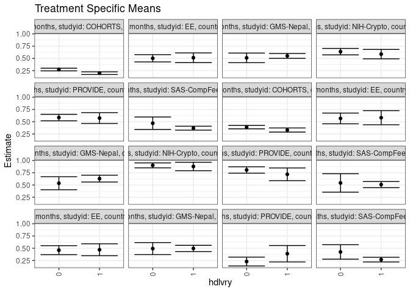

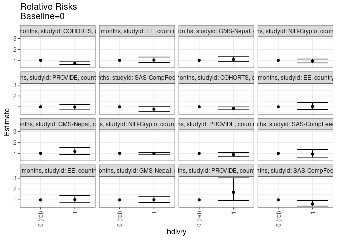

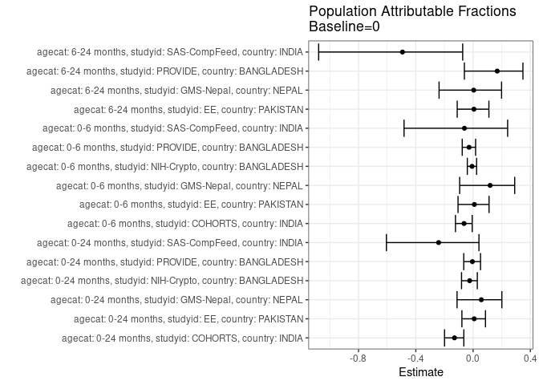

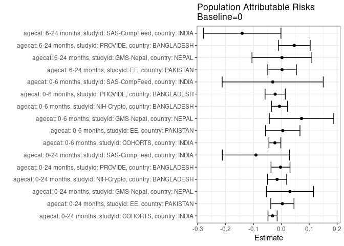

## Results Table

### Parameter: TSM

| agecat | studyid | country | intervention_level | baseline_level | estimate | ci_lower | ci_upper |
| --- | --- | --- | --- | --- | --- | --- | --- |
| 0-24 months | COHORTS | INDIA | 0 | NA | 0.2727273 | 0.2455889 | 0.2998656 |
| 0-24 months | COHORTS | INDIA | 1 | NA | 0.1992528 | 0.1723873 | 0.2261183 |
| 0-24 months | EE | PAKISTAN | 0 | NA | 0.5023474 | 0.4284041 | 0.5762908 |
| 0-24 months | EE | PAKISTAN | 1 | NA | 0.5137615 | 0.4155682 | 0.6119547 |
| 0-24 months | GMS-Nepal | NEPAL | 0 | NA | 0.5112782 | 0.4141399 | 0.6084165 |
| 0-24 months | GMS-Nepal | NEPAL | 1 | NA | 0.5514223 | 0.5022686 | 0.6005761 |
| 0-24 months | NIH-Crypto | BANGLADESH | 0 | NA | 0.6376147 | 0.5718501 | 0.7033793 |
| 0-24 months | NIH-Crypto | BANGLADESH | 1 | NA | 0.5869565 | 0.4912020 | 0.6827110 |
| 0-24 months | PROVIDE | BANGLADESH | 0 | NA | 0.5840708 | 0.5179987 | 0.6501429 |
| 0-24 months | PROVIDE | BANGLADESH | 1 | NA | 0.5731707 | 0.4637451 | 0.6825964 |
| 0-24 months | SAS-CompFeed | INDIA | 0 | NA | 0.4687500 | 0.3418739 | 0.5956261 |
| 0-24 months | SAS-CompFeed | INDIA | 1 | NA | 0.3682488 | 0.3281413 | 0.4083562 |
| 0-6 months | COHORTS | INDIA | 0 | NA | 0.3888889 | 0.3541245 | 0.4236533 |
| 0-6 months | COHORTS | INDIA | 1 | NA | 0.3298969 | 0.2880357 | 0.3717582 |
| 0-6 months | EE | PAKISTAN | 0 | NA | 0.5662651 | 0.4571111 | 0.6754190 |
| 0-6 months | EE | PAKISTAN | 1 | NA | 0.5813953 | 0.4372597 | 0.7255310 |
| 0-6 months | GMS-Nepal | NEPAL | 0 | NA | 0.5357143 | 0.4031356 | 0.6682930 |
| 0-6 months | GMS-Nepal | NEPAL | 1 | NA | 0.6296296 | 0.5602563 | 0.6990030 |
| 0-6 months | NIH-Crypto | BANGLADESH | 0 | NA | 0.9000000 | 0.8497073 | 0.9502927 |
| 0-6 months | NIH-Crypto | BANGLADESH | 1 | NA | 0.8771930 | 0.7908916 | 0.9634944 |
| 0-6 months | PROVIDE | BANGLADESH | 0 | NA | 0.8057554 | 0.7411719 | 0.8703389 |
| 0-6 months | PROVIDE | BANGLADESH | 1 | NA | 0.7173913 | 0.5880020 | 0.8467806 |
| 0-6 months | SAS-CompFeed | INDIA | 0 | NA | 0.5416667 | 0.3534523 | 0.7298810 |
| 0-6 months | SAS-CompFeed | INDIA | 1 | NA | 0.5078740 | 0.4454740 | 0.5702741 |
| 6-24 months | EE | PAKISTAN | 0 | NA | 0.4615385 | 0.3700778 | 0.5529992 |
| 6-24 months | EE | PAKISTAN | 1 | NA | 0.4696970 | 0.3480867 | 0.5913073 |
| 6-24 months | GMS-Nepal | NEPAL | 0 | NA | 0.4935065 | 0.3710770 | 0.6159360 |
| 6-24 months | GMS-Nepal | NEPAL | 1 | NA | 0.4962687 | 0.4323174 | 0.5602199 |
| 6-24 months | PROVIDE | BANGLADESH | 0 | NA | 0.2298851 | 0.1400164 | 0.3197537 |
| 6-24 months | PROVIDE | BANGLADESH | 1 | NA | 0.3888889 | 0.2217513 | 0.5560265 |
| 6-24 months | SAS-CompFeed | INDIA | 0 | NA | 0.4250000 | 0.2781131 | 0.5718869 |
| 6-24 months | SAS-CompFeed | INDIA | 1 | NA | 0.2689076 | 0.2212043 | 0.3166108 |

### Parameter: E(Y)

| agecat | studyid | country | intervention_level | baseline_level | estimate | ci_lower | ci_upper |
| --- | --- | --- | --- | --- | --- | --- | --- |
| 0-24 months | COHORTS | INDIA | NA | NA | 0.2413610 | 0.2219406 | 0.2607813 |
| 0-24 months | EE | PAKISTAN | NA | NA | 0.5062112 | 0.4470670 | 0.5653554 |
| 0-24 months | GMS-Nepal | NEPAL | NA | NA | 0.5423729 | 0.4984575 | 0.5862883 |
| 0-24 months | NIH-Crypto | BANGLADESH | NA | NA | 0.6225806 | 0.5684562 | 0.6767051 |
| 0-24 months | PROVIDE | BANGLADESH | NA | NA | 0.5811688 | 0.5245443 | 0.6377934 |
| 0-24 months | SAS-CompFeed | INDIA | NA | NA | 0.3777778 | 0.3394240 | 0.4161316 |
| 0-6 months | COHORTS | INDIA | NA | NA | 0.3658340 | 0.3390250 | 0.3926430 |
| 0-6 months | EE | PAKISTAN | NA | NA | 0.5714286 | 0.4842880 | 0.6585691 |
| 0-6 months | GMS-Nepal | NEPAL | NA | NA | 0.6081633 | 0.5464350 | 0.6698915 |
| 0-6 months | NIH-Crypto | BANGLADESH | NA | NA | 0.8934010 | 0.8497799 | 0.9370221 |
| 0-6 months | PROVIDE | BANGLADESH | NA | NA | 0.7837838 | 0.7252863 | 0.8422812 |
| 0-6 months | SAS-CompFeed | INDIA | NA | NA | 0.5107914 | 0.4514901 | 0.5700927 |
| 6-24 months | EE | PAKISTAN | NA | NA | 0.4642857 | 0.3910729 | 0.5374985 |
| 6-24 months | GMS-Nepal | NEPAL | NA | NA | 0.4956522 | 0.4389718 | 0.5523326 |
| 6-24 months | PROVIDE | BANGLADESH | NA | NA | 0.2764228 | 0.1950773 | 0.3577682 |
| 6-24 months | SAS-CompFeed | INDIA | NA | NA | 0.2846348 | 0.2390527 | 0.3302168 |

### Parameter: RR

| agecat | studyid | country | intervention_level | baseline_level | estimate | ci_lower | ci_upper |
| --- | --- | --- | --- | --- | --- | --- | --- |
| 0-24 months | COHORTS | INDIA | 0 | 0 | 1.0000000 | 1.0000000 | 1.0000000 |
| 0-24 months | COHORTS | INDIA | 1 | 0 | 0.7305936 | 0.6178743 | 0.8638764 |
| 0-24 months | EE | PAKISTAN | 0 | 0 | 1.0000000 | 1.0000000 | 1.0000000 |
| 0-24 months | EE | PAKISTAN | 1 | 0 | 1.0227214 | 0.8035045 | 1.3017464 |
| 0-24 months | GMS-Nepal | NEPAL | 0 | 0 | 1.0000000 | 1.0000000 | 1.0000000 |
| 0-24 months | GMS-Nepal | NEPAL | 1 | 0 | 1.0785172 | 0.8743494 | 1.3303598 |
| 0-24 months | NIH-Crypto | BANGLADESH | 0 | 0 | 1.0000000 | 1.0000000 | 1.0000000 |
| 0-24 months | NIH-Crypto | BANGLADESH | 1 | 0 | 0.9205505 | 0.7586400 | 1.1170163 |
| 0-24 months | PROVIDE | BANGLADESH | 0 | 0 | 1.0000000 | 1.0000000 | 1.0000000 |
| 0-24 months | PROVIDE | BANGLADESH | 1 | 0 | 0.9813378 | 0.7861226 | 1.2250301 |
| 0-24 months | SAS-CompFeed | INDIA | 0 | 0 | 1.0000000 | 1.0000000 | 1.0000000 |
| 0-24 months | SAS-CompFeed | INDIA | 1 | 0 | 0.7855974 | 0.5868019 | 1.0517404 |
| 0-6 months | COHORTS | INDIA | 0 | 0 | 1.0000000 | 1.0000000 | 1.0000000 |
| 0-6 months | COHORTS | INDIA | 1 | 0 | 0.8483063 | 0.7263434 | 0.9907484 |
| 0-6 months | EE | PAKISTAN | 0 | 0 | 1.0000000 | 1.0000000 | 1.0000000 |
| 0-6 months | EE | PAKISTAN | 1 | 0 | 1.0267194 | 0.7500166 | 1.4055060 |
| 0-6 months | GMS-Nepal | NEPAL | 0 | 0 | 1.0000000 | 1.0000000 | 1.0000000 |
| 0-6 months | GMS-Nepal | NEPAL | 1 | 0 | 1.1753086 | 0.8963966 | 1.5410035 |
| 0-6 months | NIH-Crypto | BANGLADESH | 0 | 0 | 1.0000000 | 1.0000000 | 1.0000000 |
| 0-6 months | NIH-Crypto | BANGLADESH | 1 | 0 | 0.9746589 | 0.8703902 | 1.0914184 |
| 0-6 months | PROVIDE | BANGLADESH | 0 | 0 | 1.0000000 | 1.0000000 | 1.0000000 |
| 0-6 months | PROVIDE | BANGLADESH | 1 | 0 | 0.8903339 | 0.7308597 | 1.0846054 |
| 0-6 months | SAS-CompFeed | INDIA | 0 | 0 | 1.0000000 | 1.0000000 | 1.0000000 |
| 0-6 months | SAS-CompFeed | INDIA | 1 | 0 | 0.9376136 | 0.6485807 | 1.3554507 |
| 6-24 months | EE | PAKISTAN | 0 | 0 | 1.0000000 | 1.0000000 | 1.0000000 |
| 6-24 months | EE | PAKISTAN | 1 | 0 | 1.0176768 | 0.7345535 | 1.4099258 |
| 6-24 months | GMS-Nepal | NEPAL | 0 | 0 | 1.0000000 | 1.0000000 | 1.0000000 |
| 6-24 months | GMS-Nepal | NEPAL | 1 | 0 | 1.0055970 | 0.7603005 | 1.3300337 |
| 6-24 months | PROVIDE | BANGLADESH | 0 | 0 | 1.0000000 | 1.0000000 | 1.0000000 |
| 6-24 months | PROVIDE | BANGLADESH | 1 | 0 | 1.6916667 | 0.9461403 | 3.0246424 |
| 6-24 months | SAS-CompFeed | INDIA | 0 | 0 | 1.0000000 | 1.0000000 | 1.0000000 |
| 6-24 months | SAS-CompFeed | INDIA | 1 | 0 | 0.6327237 | 0.4290456 | 0.9330925 |

### Parameter: PAR

| agecat | studyid | country | intervention_level | baseline_level | estimate | ci_lower | ci_upper |
| --- | --- | --- | --- | --- | --- | --- | --- |
| 0-24 months | COHORTS | INDIA | 0 | NA | -0.0313663 | -0.0477776 | -0.0149549 |
| 0-24 months | EE | PAKISTAN | 0 | NA | 0.0038638 | -0.0377485 | 0.0454760 |
| 0-24 months | GMS-Nepal | NEPAL | 0 | NA | 0.0310947 | -0.0532282 | 0.1154175 |
| 0-24 months | NIH-Crypto | BANGLADESH | 0 | NA | -0.0150340 | -0.0493318 | 0.0192638 |
| 0-24 months | PROVIDE | BANGLADESH | 0 | NA | -0.0029020 | -0.0369181 | 0.0311142 |
| 0-24 months | SAS-CompFeed | INDIA | 0 | NA | -0.0909722 | -0.2114429 | 0.0294984 |
| 0-6 months | COHORTS | INDIA | 0 | NA | -0.0230549 | -0.0443811 | -0.0017287 |
| 0-6 months | EE | PAKISTAN | 0 | NA | 0.0051635 | -0.0565529 | 0.0668799 |
| 0-6 months | GMS-Nepal | NEPAL | 0 | NA | 0.0724490 | -0.0430200 | 0.1879180 |
| 0-6 months | NIH-Crypto | BANGLADESH | 0 | NA | -0.0065990 | -0.0355389 | 0.0223409 |
| 0-6 months | PROVIDE | BANGLADESH | 0 | NA | -0.0219716 | -0.0582922 | 0.0143490 |
| 0-6 months | SAS-CompFeed | INDIA | 0 | NA | -0.0308753 | -0.2120406 | 0.1502900 |
| 6-24 months | EE | PAKISTAN | 0 | NA | 0.0027473 | -0.0484878 | 0.0539823 |
| 6-24 months | GMS-Nepal | NEPAL | 0 | NA | 0.0021457 | -0.1051745 | 0.1094658 |
| 6-24 months | PROVIDE | BANGLADESH | 0 | NA | 0.0465377 | -0.0104079 | 0.1034834 |
| 6-24 months | SAS-CompFeed | INDIA | 0 | NA | -0.1403652 | -0.2794203 | -0.0013102 |

### Parameter: PAF

| agecat | studyid | country | intervention_level | baseline_level | estimate | ci_lower | ci_upper |
| --- | --- | --- | --- | --- | --- | --- | --- |
| 0-24 months | COHORTS | INDIA | 0 | NA | -0.1299559 | -0.1993209 | -0.0646028 |
| 0-24 months | EE | PAKISTAN | 0 | NA | 0.0076327 | -0.0781233 | 0.0865675 |
| 0-24 months | GMS-Nepal | NEPAL | 0 | NA | 0.0573308 | -0.1120696 | 0.2009267 |
| 0-24 months | NIH-Crypto | BANGLADESH | 0 | NA | -0.0241479 | -0.0806576 | 0.0294067 |
| 0-24 months | PROVIDE | BANGLADESH | 0 | NA | -0.0049933 | -0.0652637 | 0.0518671 |
| 0-24 months | SAS-CompFeed | INDIA | 0 | NA | -0.2408088 | -0.6052517 | 0.0408940 |
| 0-6 months | COHORTS | INDIA | 0 | NA | -0.0630201 | -0.1229865 | -0.0062558 |
| 0-6 months | EE | PAKISTAN | 0 | NA | 0.0090361 | -0.1051559 | 0.1114291 |
| 0-6 months | GMS-Nepal | NEPAL | 0 | NA | 0.1191275 | -0.0936849 | 0.2905303 |
| 0-6 months | NIH-Crypto | BANGLADESH | 0 | NA | -0.0073864 | -0.0403389 | 0.0245224 |
| 0-6 months | PROVIDE | BANGLADESH | 0 | NA | -0.0280327 | -0.0757750 | 0.0175907 |
| 0-6 months | SAS-CompFeed | INDIA | 0 | NA | -0.0604460 | -0.4821519 | 0.2412750 |
| 6-24 months | EE | PAKISTAN | 0 | NA | 0.0059172 | -0.1108505 | 0.1104107 |
| 6-24 months | GMS-Nepal | NEPAL | 0 | NA | 0.0043290 | -0.2375545 | 0.1989357 |
| 6-24 months | PROVIDE | BANGLADESH | 0 | NA | 0.1683570 | -0.0607949 | 0.3480077 |
| 6-24 months | SAS-CompFeed | INDIA | 0 | NA | -0.4931416 | -1.0785098 | -0.0726299 |